# Analysis of Films during Feb 2022

## Data Analysis of Films Playing in Austin in February 2022

The following data processing and analysis will be carried out using data collected by interviewing audiences after different film screenings across different movie theaters in Austin, Texas. The data collection was carried out from February 10th-13th, so the films represent those in theathers during these dates. The purpose of the investigation was to discover audience ratings of these films and compare those with demographic factors to see if these play a role on ratings. Data was collected about some of the same films across different theaters also to see if the audiences ratings varied across areas of the city.

Below is a deeper description of each attribute:

Theater: Describes the theater location that was visited to produce the data. Three different locations were visited:

- Alamo Drafthouse located at 1120 S Lamar Blvd, Austin, TX 78704
- AMC Barton Creek Square 14 located at 2901 S Capital of Texas Hwy, Austin, TX 78746
- IPIC Theaters located at 3225 Amy Donovan Plaza, Austin, TX 78758.

Film: Describes the movie that is being rated by audiences (Note: It describes the film and not the specific screening- so not for a specific place and time). The films rated throughout the data collection are:

- *Death on the Nile (2022)* directed by Kenneth Branagh
- *Moonfall (2022)* directed by Roland Emmerich
- *Scream (2022)* directed by Matt Bettinelli-Olpin and Tyler Gillett
- *Spider-Man: No Way Home (2021)* directed by Jon Watts
- *Marry Me (2022)* directed by Kat Coiro
- *Sing 2 (2021)* directed by Garth Jennings
- *Licorice Pizza (2021)* directed by Paul Thomas Anderson
- *Blacklight (2022)* directed by Mark Williams.

Rating: Describes the score given to the films by audiences. The scale is out of 5 (and includes half ratings like out of 5 stars).

Age: Describes the age of the audience participant interviewed.

Gender: Describes the gender identification of participants (who were asked).

1. I imported Pandas and NumPy. Then I imported the csv file with the raw data.

```python
import pandas as pd
import numpy as np

df = pd.read_csv('Rawdataformovies.csv')
```

1. Then, I plotted the csv just to verify the file is correct.

```python
df.head()
```

|  | Theater | Film | Rating | Age | Gender |
| --- | --- | --- | --- | --- | --- |
| 0 | Alamo Drafthouse | Death on the Nile (2022) | 2.5 | 27 | Female |
| 1 | Alamo Drafthouse | Death on the Nile (2022) | 3.0 | 25 | Male |
| 2 | Alamo Drafthouse | Death on the Nile (2022) | 2.5 | 34 | Male |
| 3 | Alamo Drafthouse | Death on the Nile (2022) | 3.0 | 43 | Male |
| 4 | Alamo Drafthouse | Death on the Nile (2022) | 4.0 | 45 | Female |

1. Here I also verified that I could extract attributes.

```python
df['Theater']
```

```
0               Alamo Drafthouse
1               Alamo Drafthouse
2               Alamo Drafthouse
3               Alamo Drafthouse
4               Alamo Drafthouse
                 ...
95    IPIC Theaters: the Domain
96    IPIC Theaters: the Domain
97    IPIC Theaters: the Domain
98    IPIC Theaters: the Domain
99    IPIC Theaters: the Domain
Name: Theater, Length: 100, dtype: object
```

1. I isolated the data per theater and then used the describe function to find the mean rating in each theater.

```python
df[df['Theater']=='Alamo Drafthouse'].describe()
```

|  | Rating | Age |
| --- | --- | --- |
| count | 50.000000 | 50.000000 |
| mean | 3.350000 | 25.560000 |
| std | 0.887843 | 10.047154 |
| min | 2.000000 | 18.000000 |
| 25% | 2.500000 | 20.000000 |
| 50% | 3.000000 | 22.500000 |
| 75% | 4.000000 | 26.750000 |
| max | 5.000000 | 67.000000 |

```python
df[df['Theater']=='AMC: Barton Creek Square'].describe()
```

|  | Rating | Age |
| --- | --- | --- |
| count | 32.000000 | 32.000000 |
| mean | 3.953125 | 23.250000 |
| std | 0.733522 | 9.615176 |
| min | 3.000000 | 5.000000 |
| 25% | 3.000000 | 18.750000 |
| 50% | 4.000000 | 20.500000 |
| 75% | 4.500000 | 30.000000 |
| max | 5.000000 | 44.000000 |

```python
df[df['Theater']=='IPIC Theaters: the Domain '].describe()
```

|  | Rating | Age |
| --- | --- | --- |
| count | 18.000000 | 18.000000 |
| mean | 3.527778 | 38.111111 |
| std | 0.830879 | 13.995331 |
| min | 2.000000 | 18.000000 |
| 25% | 3.000000 | 28.250000 |
| 50% | 4.000000 | 38.500000 |
| 75% | 4.000000 | 42.750000 |
| max | 5.000000 | 66.000000 |

Comment: From the data we can see the different mean ratings of audiences. The mean of ratings of Alamo Drafthouse viewers was 3.35 out of 5. This is lower than IPIC Theaters: the Domain, where the mean was approximately 3.53, and AMC: Barton Creek Square, where the mean was 3.95 (almost 4).

1. I isolated the data per film and then used the describe function to find the mean rating of each film.

```python
df[df['Film']=='Death on the Nile (2022)'].describe()
```

|  | Rating | Age |
| --- | --- | --- |
| count | 15.000000 | 15.00000 |
| mean | 3.366667 | 36.80000 |
| std | 0.581460 | 9.09631 |
| min | 2.500000 | 22.00000 |
| 25% | 3.000000 | 29.50000 |
| 50% | 3.000000 | 38.00000 |
| 75% | 4.000000 | 43.00000 |
| max | 4.000000 | 51.00000 |

```python
df[df['Film']=='Moonfall (2022)'].describe()
```

|  | Rating | Age |
| --- | --- | --- |
| count | 9.000000 | 9.000000 |
| mean | 2.333333 | 21.444444 |
| std | 0.353553 | 1.943651 |
| min | 2.000000 | 19.000000 |
| 25% | 2.000000 | 20.000000 |
| 50% | 2.500000 | 21.000000 |
| 75% | 2.500000 | 23.000000 |
| max | 3.000000 | 24.000000 |

```python
df[df['Film']=='Scream (2022)'].describe()
```

|  | Rating | Age |
| --- | --- | --- |
| count | 26.000000 | 26.000000 |
| mean | 3.769231 | 23.846154 |
| std | 0.681627 | 6.297252 |
| min | 3.000000 | 18.000000 |
| 25% | 3.000000 | 19.000000 |
| 50% | 4.000000 | 21.000000 |
| 75% | 4.000000 | 27.000000 |
| max | 5.000000 | 41.000000 |

```python
df[df['Film']=='Spider-Man: No Way Home (2021)'].describe()
```

|  | Rating | Age |
| --- | --- | --- |
| count | 14.000000 | 14.000000 |
| mean | 4.214286 | 21.071429 |
| std | 0.641941 | 2.921124 |
| min | 3.000000 | 18.000000 |
| 25% | 4.000000 | 19.000000 |
| 50% | 4.000000 | 20.000000 |
| 75% | 4.875000 | 21.000000 |
| max | 5.000000 | 28.000000 |

```python
df[df['Film']=='Marry Me (2022)'].describe()
```

|  | Rating | Age |
| --- | --- | --- |
| count | 12.000000 | 12.000000 |
| mean | 3.041667 | 36.833333 |
| std | 0.655686 | 15.170745 |
| min | 2.000000 | 23.000000 |
| 25% | 2.500000 | 25.000000 |
| 50% | 3.000000 | 33.000000 |
| 75% | 3.250000 | 43.250000 |
| max | 4.000000 | 67.000000 |

```python
df[df['Film']=='Sing 2 (2021)'].describe()
```

|  | Rating | Age |
| --- | --- | --- |
| count | 10.000000 | 10.000000 |
| mean | 4.050000 | 17.800000 |
| std | 0.761942 | 11.252654 |
| min | 3.000000 | 5.000000 |
| 25% | 3.625000 | 9.750000 |
| 50% | 4.000000 | 15.500000 |
| 75% | 4.750000 | 19.500000 |
| max | 5.000000 | 38.000000 |

```python
df[df['Film']=='Licorice Pizza (2021)'].describe()
```

|  | Rating | Age |
| --- | --- | --- |
| count | 9.000000 | 9.000000 |
| mean | 4.277778 | 23.222222 |
| std | 0.666667 | 4.684490 |
| min | 3.000000 | 18.000000 |
| 25% | 4.000000 | 19.000000 |
| 50% | 4.000000 | 21.000000 |
| 75% | 5.000000 | 26.000000 |
| max | 5.000000 | 30.000000 |

```python
df[df['Film']=='Blacklight (2022)'].describe()
```

|  | Rating | Age |
| --- | --- | --- |
| count | 5.00000 | 5.000000 |
| mean | 2.70000 | 43.800000 |
| std | 0.83666 | 21.004761 |
| min | 2.00000 | 18.000000 |
| 25% | 2.00000 | 34.000000 |
| 50% | 2.50000 | 36.000000 |
| 75% | 3.00000 | 65.000000 |
| max | 4.00000 | 66.000000 |

Comments: When looking at the mean ratings in each of the movies, across theaters, Licorice Pizza (2021) held the highest audience score around 4.27, whereas Moonfall(2022) held the lowest score around 2.33.

1. Next, I imported matplotlib in order to create a visual to compare the findings above.

```python
import matplotlib.pyplot as plt
```

1. Create a bar graph to compare and contrast the averages produceed by the processing above. The first takes the mean ratings of each theater.

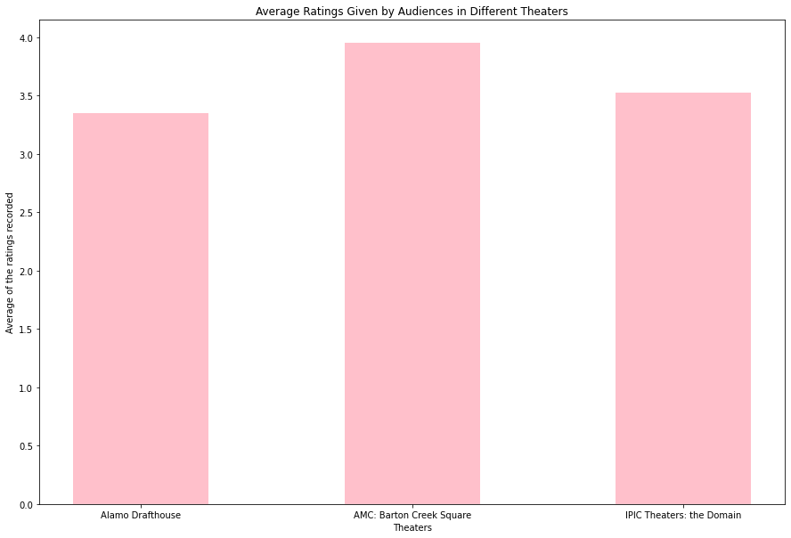

```python
plt.rcParams["figure.figsize"]=(15,10)
x= ["Alamo Drafthouse","AMC: Barton Creek Square","IPIC Theaters: the Domain"]
h= [3.35, 3.953125, 3.527778]
plt.bar(x, h, 0.5, color="pink")
plt.xlabel("Theaters")
plt.ylabel("Average of the ratings recorded")
plt.title("Average Ratings Given by Audiences in Different Theaters")
plt.show()
```

1. Create another bar graph to compare and contrast the averages produceed by the processing above. This time using the mean ratings of each film.

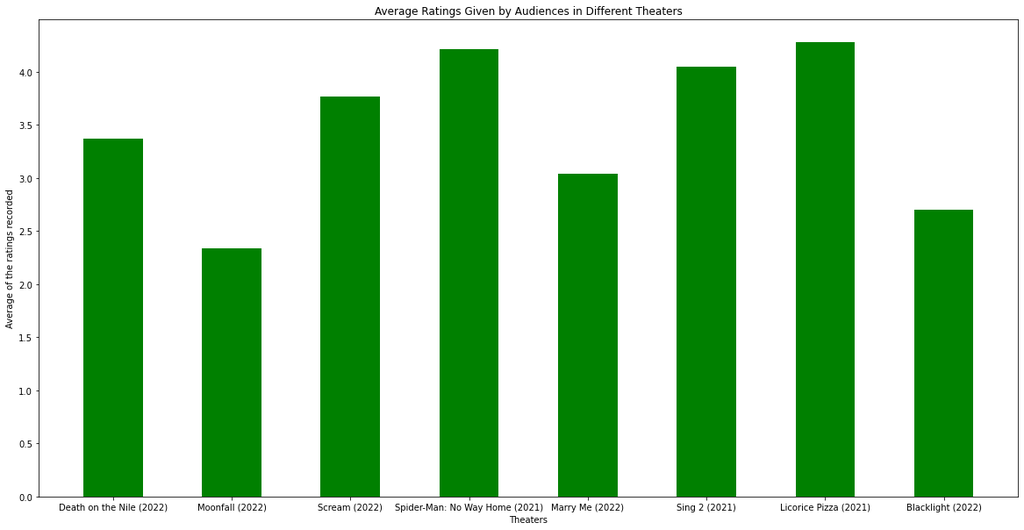

```python
plt.rcParams["figure.figsize"]=(20,10)
x= ["Death on the Nile (2022)","Moonfall (2022)","Scream (2022)", "Spider-Man: No Way Home (2021)", "Marry Me (2022)", "Sing 2 (2021)", "Licorice Pizza (2021)", "Blacklight (2022)"]
h= [3.366667, 2.333333, 3.769231, 4.214286, 3.041667, 4.05, 4.277778, 2.70000]
plt.bar(x, h, 0.5, color="green")
plt.xlabel("Theaters")
plt.ylabel("Average of the ratings recorded")
plt.title("Average Ratings Given by Audiences in Different Theaters")
plt.show()
```